# Applications & Group Projects — Week 11

## Applications & Group Projects

HEC Lausanne · Data and Code Management · Week 11

Thursday 26 November 2026

A working report becomes a small application. Then the group project begins.

Could a colleague use last week’s report without running its command-line script?

## Today: two outputs

Block 1 · 45 min — build a local Streamlit interface

Block 2 · 45 min — define a feasible four-person project

**By the end:** one working local app and one first project scope per group.

A new graded submission is not due in this session.

## What can you build with Streamlit?

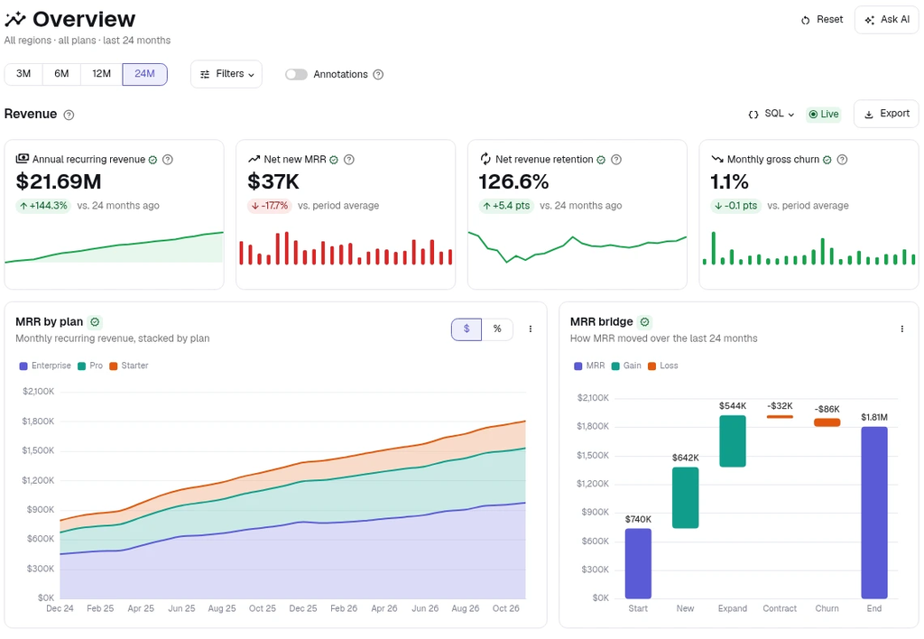

### Business dashboard

Explore revenue by region.

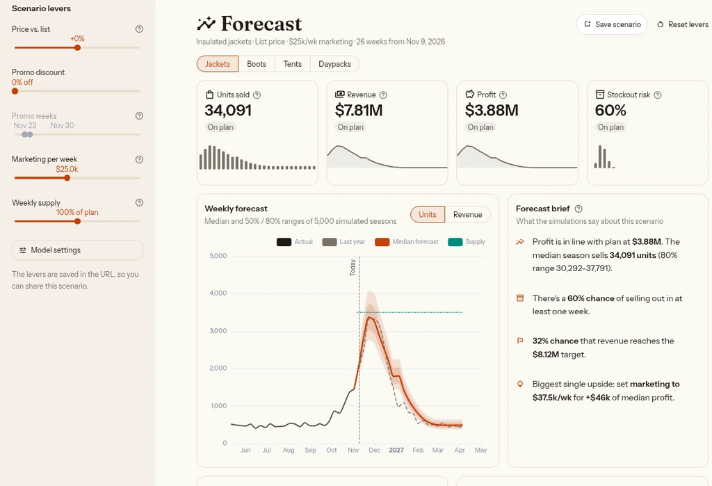

### Forecasting simulator

Test a pricing scenario.

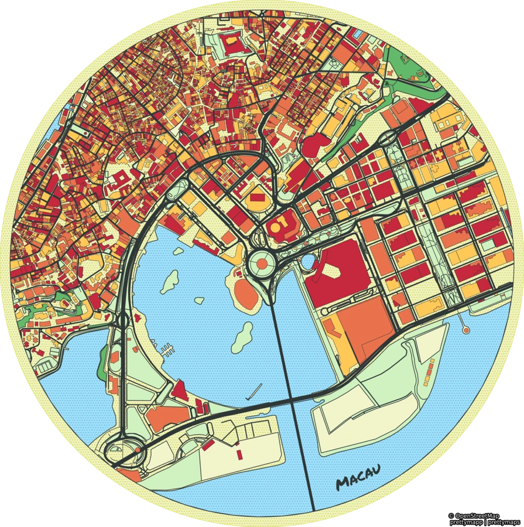

### Creative mapping

Turn streets into a print.

## Filter the data. Change a model input.

### Nimbus BI

[advanced-dashboard-demo.streamlit.app](https://advanced-dashboard-demo.streamlit.app/)

Open **Filters** and select **EMEA**.

Annual recurring revenue **$21.69M → $7.04M**

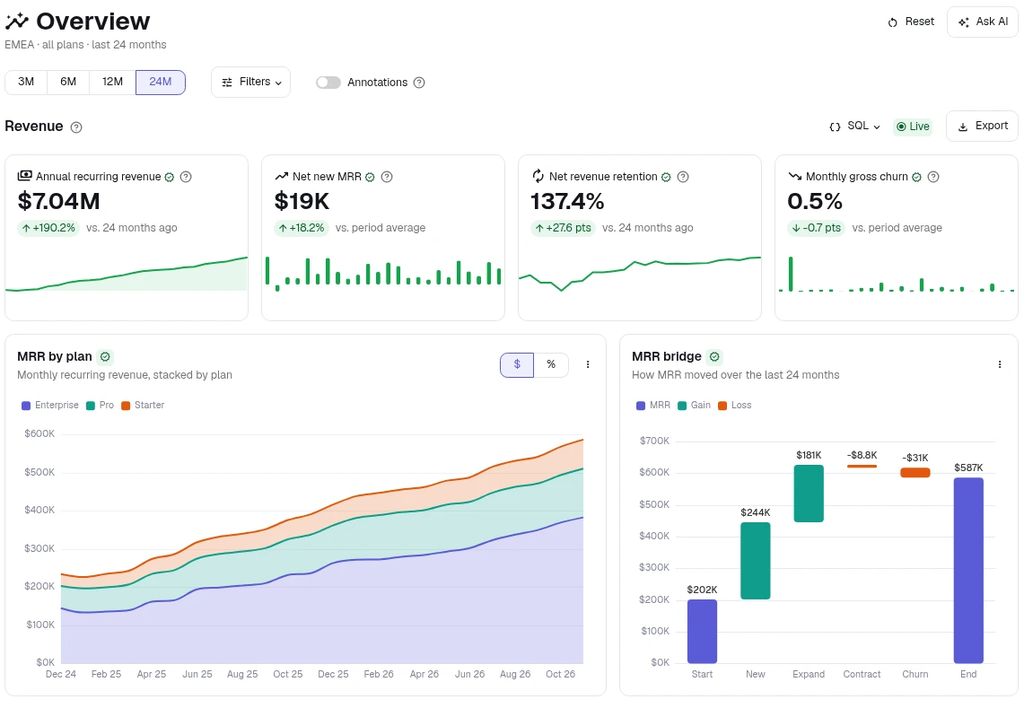

### Cairn Demand lab

[forecasting-app-demo.streamlit.app](https://forecasting-app-demo.streamlit.app/)

**Jackets** · Move **Price vs. list** to **+10%**.

Median units sold **34,091 → 29,128**

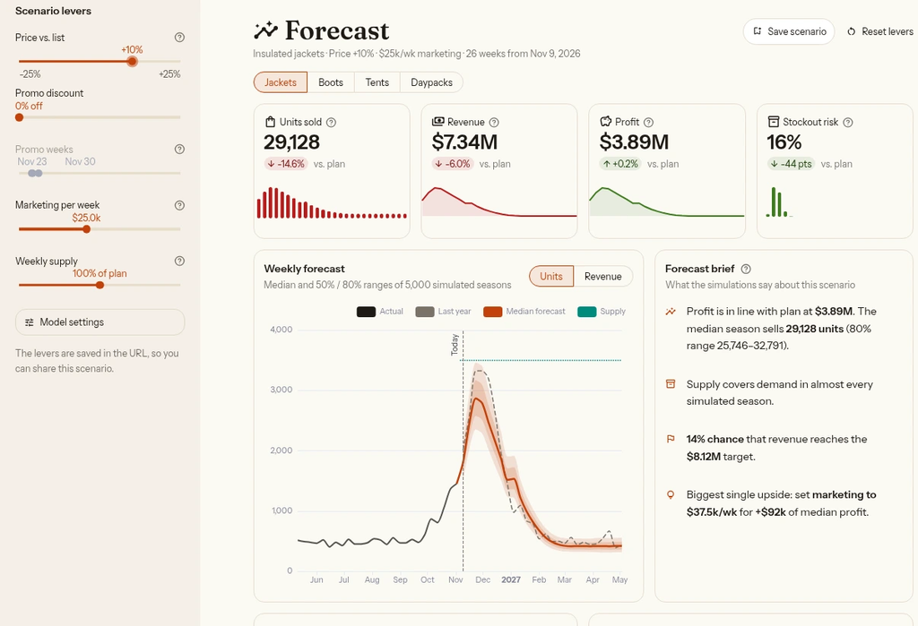

## Turn a place into a print

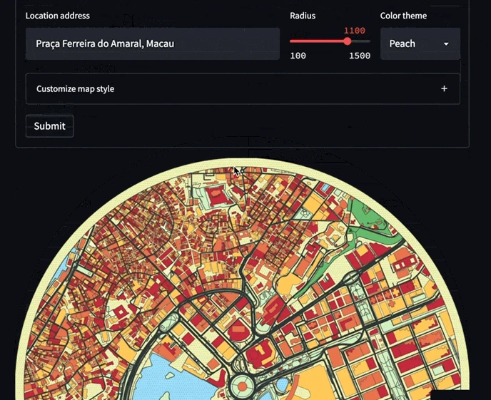

### Prettymapp

[prettymapp.streamlit.app](https://prettymapp.streamlit.app/)

Enter **Geneva, Switzerland**.

Set the radius to **1,100 m** and the color theme to **Peach**. Click **Submit**.

[Source on GitHub](https://github.com/chrieke/prettymapp)  
Fallback shown: Macau  
Map data © OpenStreetMap contributors

## The interface is built in Python

Which part would you already know how to build, and which part is new?

**Get the data**API and frozen snapshot

**Prepare and verify**Cleaning, functions and tests

**Run it again**Environments and Docker

**Make it interactive**Streamlit widgets and display

**Your turn:** use a country selector to update the population metric and chart in our World Bank app.

## Report output versus application

Three country rows. Correct growth figures. One fixed view.

**CHE 1.314%**  
DEU 0.275%  
FRA 0.262%

### Today’s application

Choose a country.

See its population and a chart.

Inspect the underlying comparison.

What changed for the user, and what should remain unchanged in the code?

## The core of `app.py`

```python
import streamlit as st
from pipeline import extract, compare
from validation import load

st.title("Population Explorer")
table = extract(load())
growth = compare(table)
st.dataframe(growth, hide_index=True)
```

An ordinary Python script produces a browser interface.

Where is the percentage-growth arithmetic?

## Running the app locally

**macOS / Linux**

```bash
.venv/bin/python -m streamlit run app.py
```

**Windows PowerShell**

```powershell
.\.venv\Scripts\python.exe -m streamlit run app.py
```

**Expected:** the browser opens at `http://localhost:8501`.

The environment must contain Streamlit and pandas. Install the supplied requirements before class.

## A · Observe the rerun

Student exercise · 6 minutes

**Where:** extracted student-pack, terminal and browser

1. Run the supplied `app.py`.
2. Choose Switzerland, then Germany.
3. Find the code that owns the growth calculation.

**Expected:** country label changes; the full table remains correct.

**Fallback:** pair with a running machine and inspect the starter source.

## Why does a widget update the page?

```python
country = st.selectbox("Country", ["CHE", "DEU", "FRA"])
st.write("Selected:", country)
```

When the user picks another option, Streamlit normally runs the script again from top to bottom.

The selected value changes on the rerun. Keep expensive or stateful work deliberate.

Docs: docs.streamlit.io/get-started/fundamentals/main-concepts

## Displayed numbers versus calculations

```python
selected = growth.loc[growth.country_code == code].iloc[0]

st.metric(
    "2024 population",
    f"{selected.population_2024:,.0f}",
    f"{selected.growth_pct:.3f}%"
)
```

The interface formats the validated result. `compare()` retains full precision.

CHE: 9,005,582 persons and 1.314% displayed.

## B · Make the selector useful

Student exercise · 9 minutes

**Goal:** add a metric and a 2023/2024 bar chart for the selected country.

**Where:** `app.py`, beneath the existing selector

**Keep:** `extract()`, `compare()`, validation and frozen data unchanged.

**Hint:**

```python
selected = growth.loc[growth.country_code == code].iloc[0]
st.metric("2024 population", f"{selected.population_2024:,.0f}",
          f"{selected.growth_pct:.3f}%")
# Then use st.bar_chart() on the two years in table.
```

**Expected:** country selection changes both outputs.

## When the source contains a null

Suppose one of the six population values is unavailable.

**Would you rather see:**

- an attractive chart treating missing as zero?
- a useful explanation that the comparison cannot be computed?

```python
except ValueError as error:
    st.error(f"The data could not be used: {error}")
    st.stop()
```

Validation determines whether a result is valid. The app explains the failure to the user.

## Checkpoint: an app with a trustworthy core

```bash
python checks.py pipeline.py
python my-check.py pipeline.py
```

**Before sharing:** document the launch command, environment and source.

Does a working page prove the report is right?

## The group project begins

Block 2 · 45 minutes · nine groups of four

Build something a colleague can run, inspect and continue.

What will be your smallest useful result by next Thursday?

## What a colleague should receive

**Source**Recorded data and provenance

**Logic**Modular code and checks

**Product**Usable app, dashboard or report

**Handover**Repo, environment, instructions

**Project success has two audiences:** the user who explores the result and the colleague who inherits the repository.

## A feasible minimum

**One concrete question. One accessible data source. One interaction that changes a useful result.**

### A credible first version

A prepared dataset, a reproducible transformation, a selector and one honest chart.

### A risky starting point

Many live APIs, scraping, accounts, machine learning and deployment before the data have been checked.

## Evidence a project can be trusted

| Question | Useful evidence |
| --- | --- |
| Where did the data come from? | Source, retrieval record, saved snapshot |
| Is the calculation right? | Independent check with an expected result |
| Can someone run it? | Fresh-clone instructions and environment |
| Can someone change it? | Small modules, readable commits, code review |

## Four people, one shared project

| Leading responsibility | A second person reviews |
| --- | --- |
| Data collection and provenance | Checks the source and assumptions |
| Transformations and tests | Checks a known example |
| App and usability | Tries a real user task |
| Environment and handover | Recreates it from a fresh clone |

**All four should be able to explain the whole path.**

## Scope clinic: two project ideas

### Too broad

“Predict every Swiss city’s housing prices using scraped live listings and a complex model.”

Unknown access, legal constraints, many dependencies and uncertain validation.

### Feasible first version

“Compare published rent statistics by canton and year, with one filter and a source note.”

One verifiable dataset, a simple question and a reproducible display.

Which risk should this team check first?

## Three project sessions ahead

| Date | Proposed checkpoint |
| --- | --- |
| **26 Nov** | Question, data source and first scope |
| **3 Dec** | Repository with a runnable first version |
| **10 Dec** | Checks, documentation, peer handover |
| **17 Dec** | Presentation |

These are planning targets. Formal requirements and deadlines remain those published on Moodle.

## Project canvas

Team workshop · 15 minutes

Use the supplied one-page worksheet.

1. **User and question** — What decision will the app support?
2. **Data** — Can you access, preserve and verify it?
3. **Minimum product** — What changes when the user clicks?
4. **Check and handover** — How will another person trust and run it?
5. **Next issue** — One task, a lead and a reviewer

## Feedback before coding

**Two volunteer groups:** 2-minute proposal each.

Listeners provide:

- one thing that is already feasible;
- one high-risk assumption to check;
- one concrete next action.

If nobody is ready to present, exchange canvases with a neighbouring group.

## First next action

**Before next week:**

- a question worth answering;
- a reachable data source;
- one GitHub issue with a lead and reviewer.